# lunchtime7 slides

- **SSC Lunch Time Python**
- [2](https://ssciwr.github.io/lunch-time-python/lunchtime2/lunchtime2.slides.html)
- [3](https://ssciwr.github.io/lunch-time-python/lunchtime3/lunchtime3.slides.html)
- [4](https://ssciwr.github.io/lunch-time-python/lunchtime4/lunchtime4.slides.html)
- [5](https://ssciwr.github.io/lunch-time-python/lunchtime5/lunchtime5.slides.html)
- [6](https://ssciwr.github.io/lunch-time-python/lunchtime6/lunchtime6.slides.html)
- [7](https://ssciwr.github.io/lunch-time-python/lunchtime7/lunchtime7.slides.html)
- [8](https://ssciwr.github.io/lunch-time-python/lunchtime8/lunchtime8.slides.html)
- [9](https://ssciwr.github.io/lunch-time-python/lunchtime9/lunchtime9.slides.html)
- [10](https://ssciwr.github.io/lunch-time-python/lunchtime10/lunchtime10.slides.html)
- [11](https://ssciwr.github.io/lunch-time-python/lunchtime11/lunchtime11.slides.html)
- [12](https://ssciwr.github.io/lunch-time-python/lunchtime12/lunchtime12.slides.html)
- [13](https://ssciwr.github.io/lunch-time-python/lunchtime13/lunchtime13.slides.html)
- [14](https://ssciwr.github.io/lunch-time-python/lunchtime14/lunchtime14.slides.html)

# Lunch Time Python

## Lunch 7: matplotlib

[matplotlib](https://matplotlib.org/) is a plotting library for Python and the NumPy library. It is easy to use and can be used to generate scatter or bar plots, density maps and even 3D plots in publication quality.

*Press `Spacebar` to go to the next slide (or `?` to see all navigation shortcuts)*

[Lunch Time Python](https://ssciwr.github.io/lunch-time-python/), [Scientific Software Center](https://ssc.iwr.uni-heidelberg.de), [Heidelberg University](https://www.uni-heidelberg.de/)

## Advantages of matplotlib:

- matplotlib is mostly used in conjunction with [pyplot](https://matplotlib.org/stable/api/_as_gen/matplotlib.pyplot.html) - a matplotlib module - that provides an easy-to-use interface
- Very versatile, works with many types of data
- Directly plot NumPy functions and arrays
- Many export options
- Customizable
- Can be used with additional toolkits that extend the functionality, like [seaborn](https://seaborn.pydata.org/)

## matplotlib installation

Available via pip:  
`python -m pip install -U matplotlib`  
Or install via conda:  
`conda install matplotlib`

# Basic plots

Plot the sin and cos over a range of angles. For this, we also need numpy.

```python
import numpy as np
import matplotlib.pyplot as plt
```

```python
xvals = np.arange(0, 2 * np.pi, 0.1)
```

```python
plt.plot(xvals, np.sin(xvals))
plt.plot(xvals, np.cos(xvals))
```

[output not shown]

## Running inside a script

Or more generally, if you want to suppress the output (return) of the `plt()` function.

```python
plt.plot(xvals, np.sin(xvals))
plt.plot(xvals, np.cos(xvals))
plt.show()
```

[output not shown]

`plt.show()` closes the plot; if you plot using a script and not a notebook, place one `plt.show()` command at the end of your script.

## Running inside a notebook: static images

You can plot static images inside your notebook using the `%matplotlib inline` magic: You only need to run this once. It is not always necessary to put this, but it makes it clear which Matplotlib backend should be used.

```python
%matplotlib inline
```

```python
plt.plot(xvals, np.sin(xvals))
plt.plot(xvals, np.cos(xvals))
plt.show()
```

[output not shown]

## Scatter plot

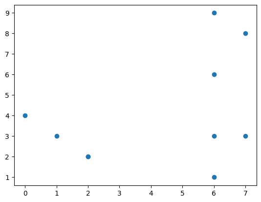

```python
xvals = np.random.randint(10, size=10)
yvals = np.random.randint(10, size=10)
plt.scatter(xvals, yvals)
plt.show()
```

## Bar plot

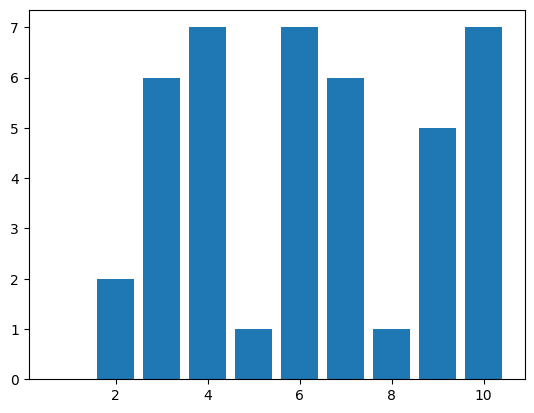

```python
xvals = np.linspace(1, 10, 10)
yvals = np.random.randint(10, size=10)
plt.bar(xvals, yvals)
plt.show()
```

## Customizing plots

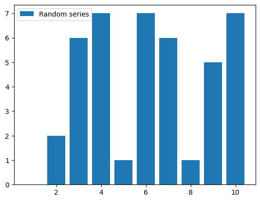

```python
plt.bar(xvals, yvals, label="Random series")
plt.legend()
plt.show()
```

## Customizing plots

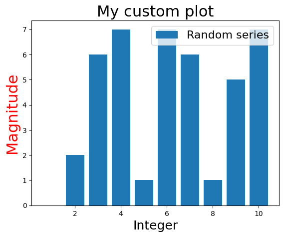

```python
plt.bar(xvals, yvals, label="Random series")
plt.legend(fontsize=16, loc="upper right")
plt.xlabel("Integer", fontsize=18)
plt.ylabel("Magnitude", fontsize=22, color="red")
plt.title("My custom plot", fontsize=22)
plt.show()
```

## Customizing plots

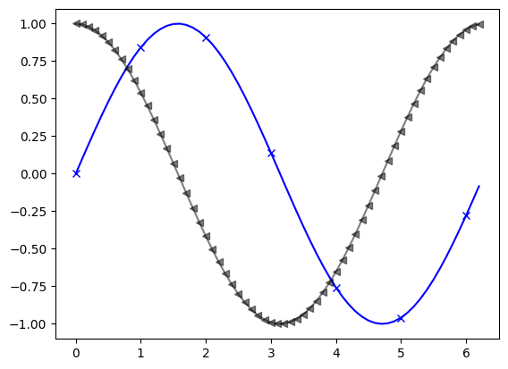

```python
xvals = np.arange(0, 2 * np.pi, 0.1)
plt.plot(xvals, np.sin(xvals), marker="x", markevery=10, color="blue")
plt.plot(xvals, np.cos(xvals), marker="<", color="black", alpha=0.5)
plt.show()
```

You can set x- and y-limits, annotate points on the plot, change the axis position and intersection, add a grid in the background, ...  
A list of available markers is found [here](https://matplotlib.org/2.0.2/api/markers_api.html) and named colors [here](https://matplotlib.org/stable/gallery/color/named_colors.html).

# Figure class: Advanced plots with the artist layer

A `Figure` in matplotlib is the whole plot (or window in the user interface) and can contain multiple plots. By accessing the **Artist layer** ("object-based plotting"), you can access more customizing options than with the basic `plt.xxx` **Scripting layer** ("procedural plotting") (see https://matplotlib.org/1.5.1/faq/usage_faq.html#parts-of-a-figure).

This also allows you to include multiple plots in one Figure.

[figure not shown]

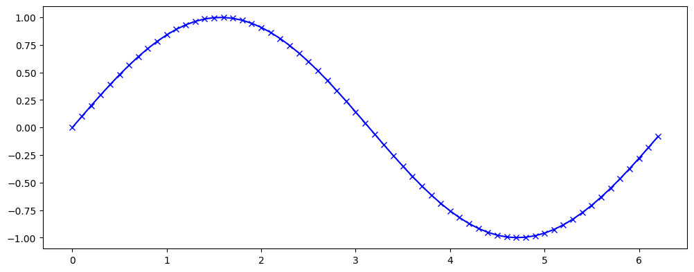

```python
fig = plt.figure(figsize=(12, 10))  # width = 12 inches and height = 10 inches
# create one axes object
ax1 = fig.add_subplot(211)  # (2, 1, 1) no of rows, no of columns, no of plots
ax1.plot(xvals, np.sin(xvals), marker="x", color="blue")
plt.show()
```

It is also possible to use `add_axes()` instead of `add_subplot()`, but not recommended as with the latter, matplotlib takes care of the exact position of the axes in the figure.

## Several subplots

Using `add_subplot()`, we can add one `axes` object at a time:

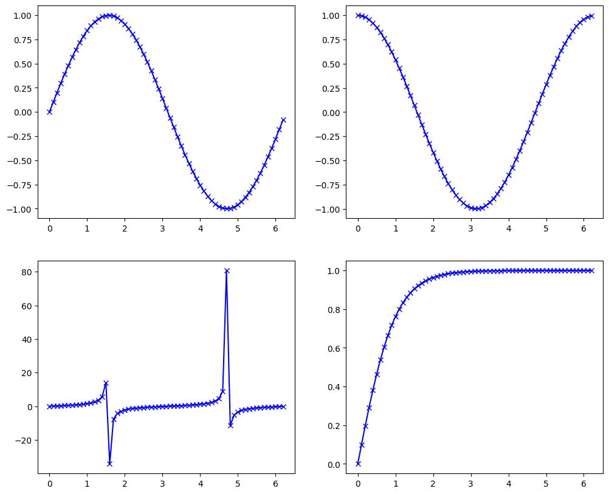

```python
fig = plt.figure(figsize=(12, 10))
ax1 = fig.add_subplot(221)
ax1.plot(xvals, np.sin(xvals), marker="x", color="blue")
ax2 = fig.add_subplot(222)
ax2.plot(xvals, np.cos(xvals), marker="x", color="blue")
ax3 = fig.add_subplot(223)
ax3.plot(xvals, np.tan(xvals), marker="x", color="blue")
ax4 = fig.add_subplot(224)
ax4.plot(xvals, np.tanh(xvals), marker="x", color="blue")
plt.show()
```

## A more practical way to add multiple subplots

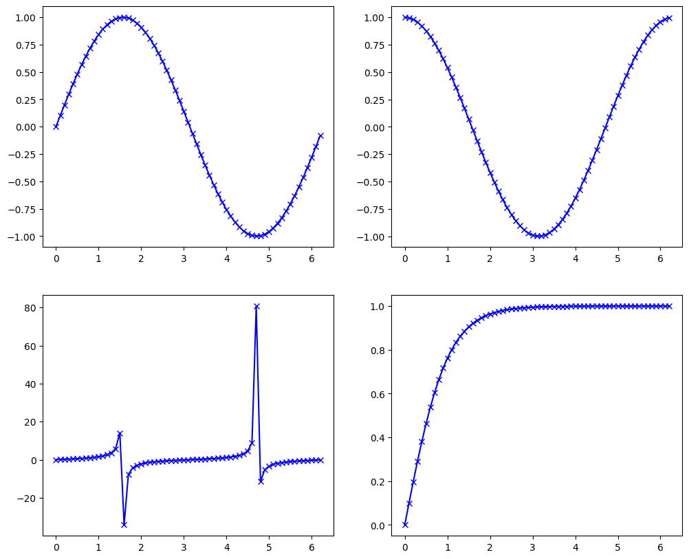

```python
fig, ax = plt.subplots(figsize=(12, 10), nrows=2, ncols=2)
ax[0, 0].plot(xvals, np.sin(xvals), marker="x", color="blue")
ax[0, 1].plot(xvals, np.cos(xvals), marker="x", color="blue")
ax[1, 0].plot(xvals, np.tan(xvals), marker="x", color="blue")
ax[1, 1].plot(xvals, np.tanh(xvals), marker="x", color="blue")
plt.savefig("my_figure.pdf", bbox_inches="tight")
plt.savefig("my_figure.jpg", dpi=300, bbox_inches="tight")
plt.show()
```

# 2D plots

```python
def myfunc(x, y):
    return np.sin(np.sqrt(5) + x) * y


mf = 16
# the x and y values need to be spanned on a 2D mesh
num1 = np.arange(-5, 5, 0.1)
num2 = np.arange(-5, 5, 0.1)
X, Y = np.meshgrid(num1, num2)
```

```python
print(X[0])
print(Y[0])
```

```
[-5.00000000e+00 -4.90000000e+00 -4.80000000e+00 -4.70000000e+00
 -4.60000000e+00 -4.50000000e+00 -4.40000000e+00 -4.30000000e+00
 -4.20000000e+00 -4.10000000e+00 -4.00000000e+00 -3.90000000e+00
 -3.80000000e+00 -3.70000000e+00 -3.60000000e+00 -3.50000000e+00
 -3.40000000e+00 -3.30000000e+00 -3.20000000e+00 -3.10000000e+00
 -3.00000000e+00 -2.90000000e+00 -2.80000000e+00 -2.70000000e+00
 -2.60000000e+00 -2.50000000e+00 -2.40000000e+00 -2.30000000e+00
 -2.20000000e+00 -2.10000000e+00 -2.00000000e+00 -1.90000000e+00
 -1.80000000e+00 -1.70000000e+00 -1.60000000e+00 -1.50000000e+00
 -1.40000000e+00 -1.30000000e+00 -1.20000000e+00 -1.10000000e+00
 -1.00000000e+00 -9.00000000e-01 -8.00000000e-01 -7.00000000e-01
 -6.00000000e-01 -5.00000000e-01 -4.00000000e-01 -3.00000000e-01
 -2.00000000e-01 -1.00000000e-01 -1.77635684e-14  1.00000000e-01
  2.00000000e-01  3.00000000e-01  4.00000000e-01  5.00000000e-01
  6.00000000e-01  7.00000000e-01  8.00000000e-01  9.00000000e-01
  1.00000000e+00  1.10000000e+00  1.20000000e+00  1.30000000e+00
  1.40000000e+00  1.50000000e+00  1.60000000e+00  1.70000000e+00
  1.80000000e+00  1.90000000e+00  2.00000000e+00  2.10000000e+00
  2.20000000e+00  2.30000000e+00  2.40000000e+00  2.50000000e+00
  2.60000000e+00  2.70000000e+00  2.80000000e+00  2.90000000e+00
  3.00000000e+00  3.10000000e+00  3.20000000e+00  3.30000000e+00
  3.40000000e+00  3.50000000e+00  3.60000000e+00  3.70000000e+00
  3.80000000e+00  3.90000000e+00  4.00000000e+00  4.10000000e+00
  4.20000000e+00  4.30000000e+00  4.40000000e+00  4.50000000e+00
  4.60000000e+00  4.70000000e+00  4.80000000e+00  4.90000000e+00]
[-5. -5. -5. -5. -5. -5. -5. -5. -5. -5. -5. -5. -5. -5. -5. -5. -5. -5.
 -5. -5. -5. -5. -5. -5. -5. -5. -5. -5. -5. -5. -5. -5. -5. -5. -5. -5.
 -5. -5. -5. -5. -5. -5. -5. -5. -5. -5. -5. -5. -5. -5. -5. -5. -5. -5.
 -5. -5. -5. -5. -5. -5. -5. -5. -5. -5. -5. -5. -5. -5. -5. -5. -5. -5.
 -5. -5. -5. -5. -5. -5. -5. -5. -5. -5. -5. -5. -5. -5. -5. -5. -5. -5.
 -5. -5. -5. -5. -5. -5. -5. -5. -5. -5.]
```

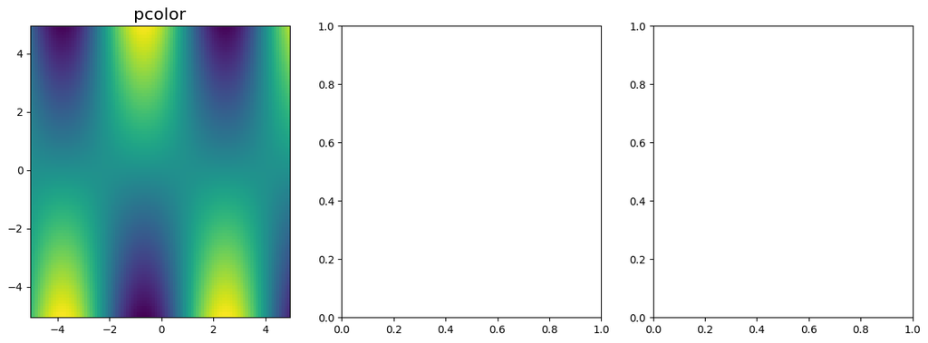

```python
fig, ax = plt.subplots(figsize=(15, 5), nrows=1, ncols=3)
ax[0].pcolor(X, Y, myfunc(X, Y), cmap="viridis")
ax[0].set_title("pcolor", fontsize=mf)
plt.show()
```

`pcolor` is the slowest plotting method of the three, but is more flexible in terms of the data mesh.

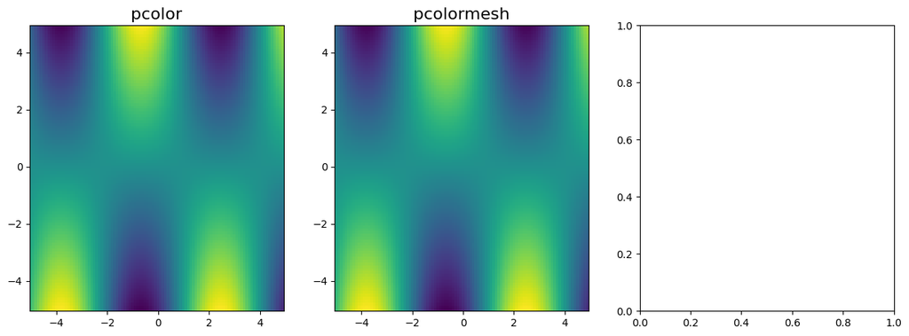

```python
fig, ax = plt.subplots(figsize=(15, 5), nrows=1, ncols=3)

ax[0].pcolor(X, Y, myfunc(X, Y), cmap="viridis")
ax[0].set_title("pcolor", fontsize=mf)

ax[1].pcolormesh(X, Y, myfunc(X, Y), cmap="viridis")
ax[1].set_title("pcolormesh", fontsize=mf)

plt.show()
```

`pcolormesh` is basically identical to `pcolor` but faster.

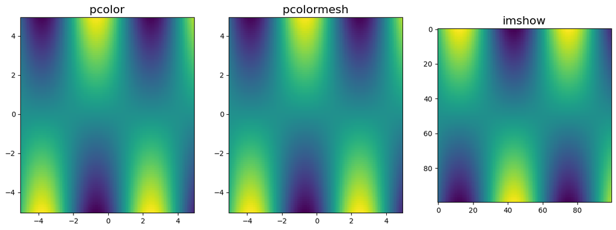

```python
fig, ax = plt.subplots(figsize=(15, 5), nrows=1, ncols=3)

ax[0].pcolor(X, Y, myfunc(X, Y), cmap="viridis")
ax[0].set_title("pcolor", fontsize=mf)

ax[1].pcolormesh(X, Y, myfunc(X, Y), cmap="viridis")
ax[1].set_title("pcolormesh", fontsize=mf)

ax[2].imshow(myfunc(X, Y))
ax[2].set_title("imshow", fontsize=mf)

plt.show()
```

`imshow` is the fastest of the three methods. Note that the image is flipped compared to `pcolor` and `pcolormesh` and that the axis range is specified differently.

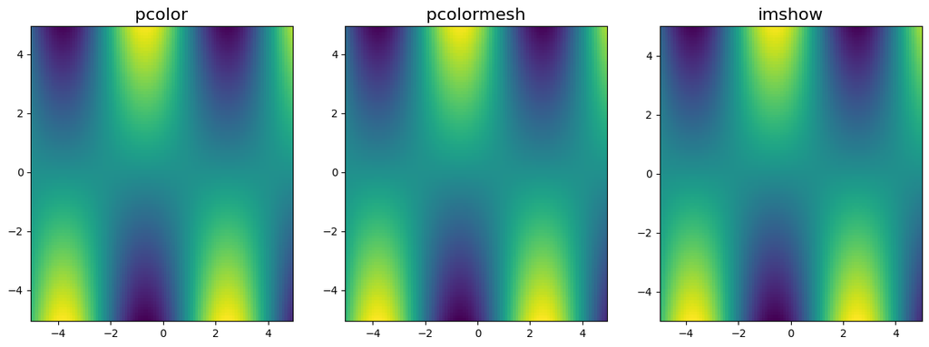

```python
fig, ax = plt.subplots(figsize=(15, 5), nrows=1, ncols=3)

ax[0].pcolor(X, Y, myfunc(X, Y), cmap="viridis")
ax[0].set_title("pcolor", fontsize=mf)

ax[1].pcolormesh(X, Y, myfunc(X, Y), cmap="viridis")
ax[1].set_title("pcolormesh", fontsize=mf)

ax[2].imshow(myfunc(X, Y), extent=[-5, 5, -5, 5], origin="lower", aspect="auto")
ax[2].set_title("imshow", fontsize=mf)

plt.show()
```

Here, we have repositioned the origin of `imshow` to match `pcolor` and `pcolormesh`, and further adjusted the aspect ratio and tick labels.

## Imshow with contour bar

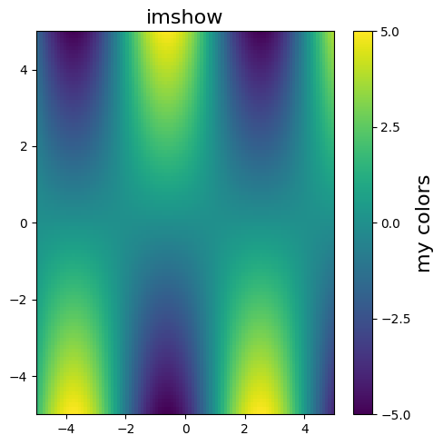

```python
fig, ax = plt.subplots(figsize=(5, 5))

c = ax.imshow(myfunc(X, Y), extent=[-5, 5, -5, 5], origin="lower", aspect="auto")
cbar = plt.colorbar(c)
cbar.set_ticks([-5, -2.5, 0, 2.5, 5])
cbar.set_label("my colors", rotation=90, fontsize=mf)

ax.set_title("imshow", fontsize=mf)
plt.tight_layout()
plt.show()
```

# 3D plots

For 3D plots, you will need to import the `mplot3d` [module](https://matplotlib.org/stable/tutorials/toolkits/mplot3d.html). Then, when the axes are created, passing the `projection="3d"` keyword enables a 3D axes.

```python
from mpl_toolkits.mplot3d import Axes3D
from matplotlib import cm
```

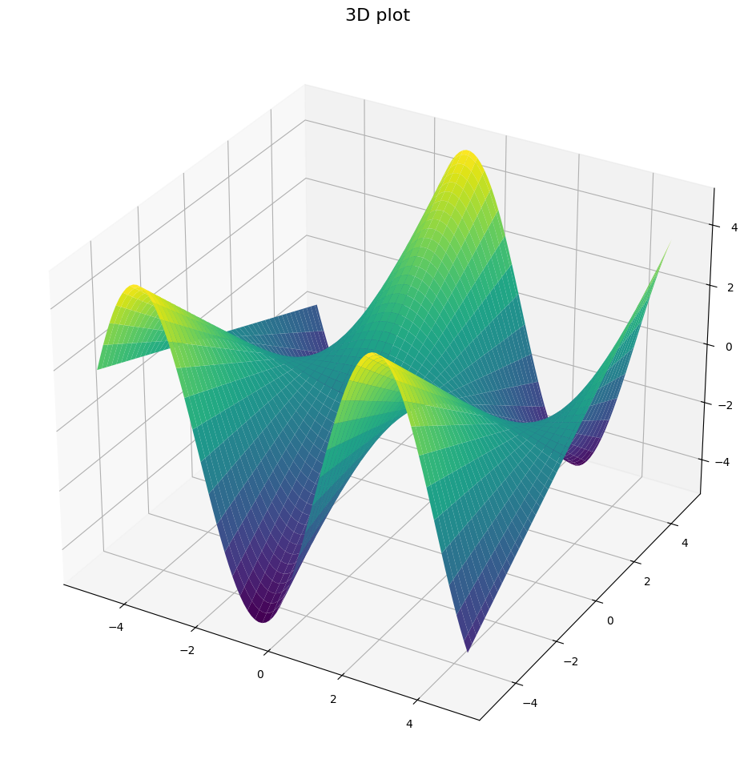

```python
fig = plt.figure(figsize=(12, 12))
# fig, ax = plt.subplots(figsize=(12,12),subplot_kw=dict(projection='3d'))

ax = fig.add_subplot(projection="3d")
ax.plot_surface(X, Y, myfunc(X, Y), cmap=cm.viridis)


ax.set_title("3D plot", fontsize=mf)
plt.show()
```

The 3D plots of matplotlib are quite powerful but has its limitations: If it comes to plotting more than one set of data (two functions in one figure), then it will likely be rendered incorrectly.

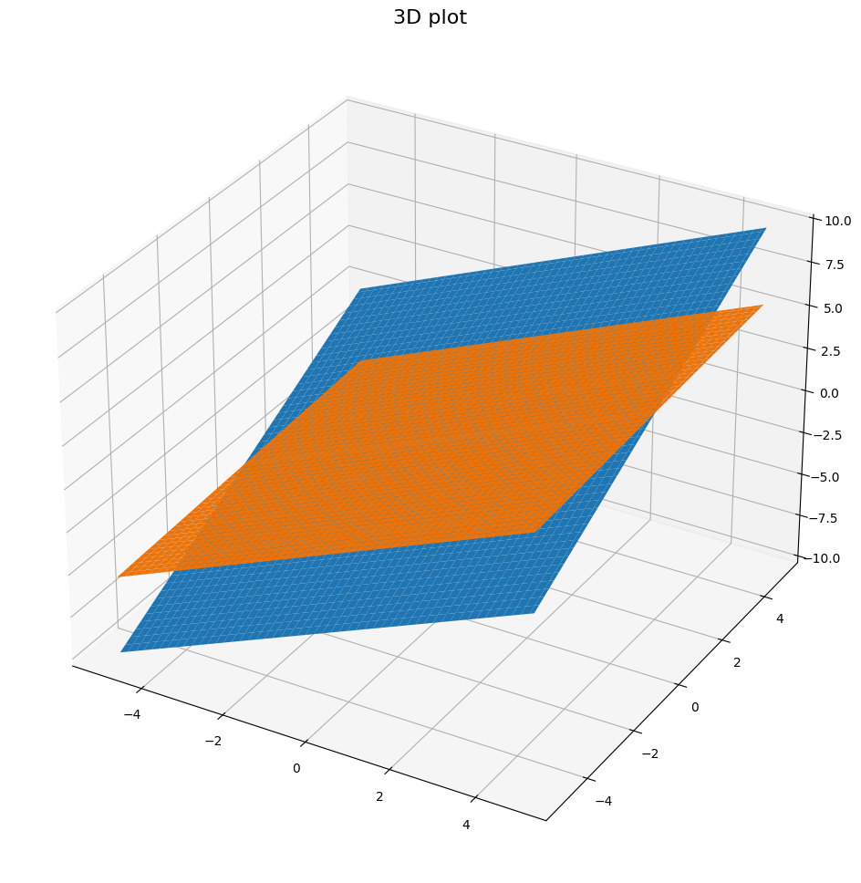

```python
fig = plt.figure(figsize=(12, 12))

ax = fig.add_subplot(projection="3d")
ax.plot_surface(X, Y, X + Y)
ax.plot_surface(X, Y, X + 0.1 * Y)


ax.set_title("3D plot", fontsize=mf)
plt.show()
```

For more advanced 3D plots, resort to [`Mayavi`](https://docs.enthought.com/mayavi/mayavi/).

# Interactive plots

```python
%matplotlib notebook
```

```python
fig, ax = plt.subplots(nrows=2, ncols=2)
ax[0, 0].plot(xvals, np.sin(xvals), marker="x", color="blue")
ax[0, 1].plot(xvals, np.cos(xvals), marker="x", color="blue")
ax[1, 0].plot(xvals, np.tan(xvals), marker="x", color="blue")
ax[1, 1].plot(xvals, np.tanh(xvals), marker="x", color="blue")
plt.show()
```

# Further references

- Anatomy of matplotlib: https://nbviewer.org/github/matplotlib/AnatomyOfMatplotlib/tree/master/
- Matplotlib tutorial by Nicolas Rougier: https://github.com/rougier/matplotlib-tutorial
- Creating animations with Matplotlib: https://matplotlib.org/stable/api/animation_api.html